# Einführung in das Buildsystem Bazel

https://codeberg.org/obruns/tuebix-2025

Oliver Bruns

July 5th, 2025

## Note

These reveal.js-based slides are provided as a means to simplify distribution. I had actually presented this content straight out of NeoVim.

## Schedule

- A quick recap of established (and well-known?) build systems: Make and CMake
- Bazel: Live Demo
- Case Study: From 2h to five minutes
- What to consider when migrating an existing proprietary project
- Bazel: introspecting the introspection facilities
- Bazel vs Distribution Maintainers

## Questions

- Feel free to interrupt me.
- If we have many questions, the slot for questions at the end may be shorter than 10 minutes.

## About me

[figure not shown]

## Goals and non-goals

- Goal: To equip the audience with a seed of knowledge for when their current build system stops scaling.
- Non-goal: To make the audience replace their existing build systems because of their shortcomings presented here.
  - Let me stress this point: *Make and CMake are fine tools (when used appropriately) until they stop scaling.*

Image Credit: [xkcd: Compiling](https://xkcd.com/303/)

## Quick show of hands so that I know how detailed I should be

[figure not shown]

- You are tasked to create a build system for the following project (source code provided).
- The only content that you can access on the internet is
  - The GNU Make manual.
  - The CMake documentation.
  - The Ninja documentation.
  - The Bazel documentation.
- IOW, you know the systems but you don’t necessarily know the API by heart.
- **Do you think that you can provide a minimum workable solution within thirty minutes?**

## References

- [Recursive Make considered harmful](https://accu.org/journals/overload/14/71/miller_2004/)
- [GNU make: Reference Manual](https://www.gnu.org/software/make/manual/html_node/index.html)
- [CMake documentation](https://cmake.org/cmake/help/latest/index.html)
- [Software Engineering at Google: Build Systems and Build Philosophy](https://abseil.io/resources/swe-book/html/ch18.html)
- [YouTube: bazelcon](https://www.youtube.com/results?search_query=bazelcon)
- [Using Bazel](https://bazel.build/docs)
- [Bazel: Common C++ Use Cases](https://bazel.build/versions/8.3.0/tutorials/cpp-use-cases)
- [Bazel: Reference](https://bazel.build/reference)
- John Lakos: Large-Scale C++
- Rafał Świdziński: Modern CMake for C++

## Make, Problems and Mitigations

- rule-based
- comes with implicit rules
- too easy to forget to declare some dependencies (a.k.a prerequisites)
- environment variables leak to all action (a.k.a recipe) executions
- Make does not rebuild on environment changes (e.g. `CXX=other-compiler make`)
- changes to the `Makefile` are not picked up by Make
- timestamps are the only attribute that determines a rebuild
  - can be mitigated by using `ccache` which is still executed but faster than expensive compiler calls

## CMake, Problems and Mitigations

- a buildsystem generator, sometimes also called a meta-buildsystem
- (CMake is used here as one example for the group of buildsystem generators; see also: Meson, …)
- commonly generates “UNIX Makefiles” and “Ninja” on Linux-based operating systems
- fundamentally has the same problems as Make

## Task-based

- Ant
- Maven
- Gradle
- Grunt
- Rake
- …

## Artifact-based

- Blaze
  - Bazel
  - Pants
  - Buck/Buck2
- Make, CMake and Meson (caveats apply)

https://abseil.io/resources/swe-book/html/ch18.html#task-based_build_systems

## { Fast, Correct } — Choose two

- functional: `action :: [input] -> [output]`
- types of inputs: files, environment variables, command line arguments, tools, …
- phased: loading, analysis, execution phases (but: Project Skymeld)
- sandboxed
- language-agnostic
- extensible
- remote caching (`ccache` on steroids)
- remote execution (`distcc` on steroids)

```
                                         It's about time for a demo
```

## Live Demo: Summary

- Starlark
  - A subset of Python.
  - Declarative in `BUILD` files, imperative in `*.bzl` files.
- Powerful set of subcommands.
  - `build`, `run`, `test`, `query`, `cquery`, `aquery`, `coverage`, …
- Bazel creates sandboxes for each action execution.
  - Different sandbox implementations with varying degree of isolation.
- Tool command lines are relative to the sandbox root.
- The auto-generated C++ toolchain *is not* hermetic.
- Bazel provides additional architecture tools
  - Visibility
  - Layering Check (requires compiler support)

## Case Study: Opportunities and Goals

- This “zoo of build systems” offers *a lot* of low-hanging fruits.
- Perfect scheduling across all cores on a host.
  - Requires a single dependency graph, i.e. all phases are to be merged into one.
- Enabling remote caching as the most primitive form of distributed builds.
- (Future) Enabling of remote execution to scale the builds on demand.

## Case Study: Status Quo – illustrated

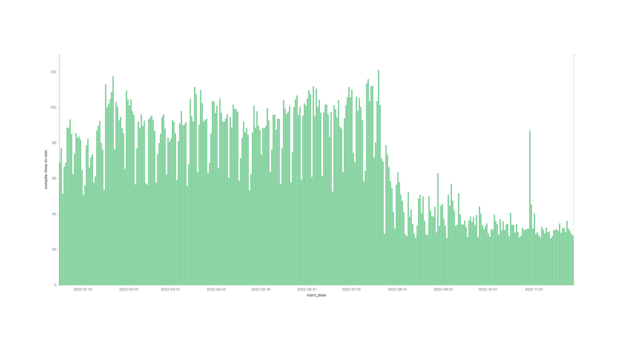

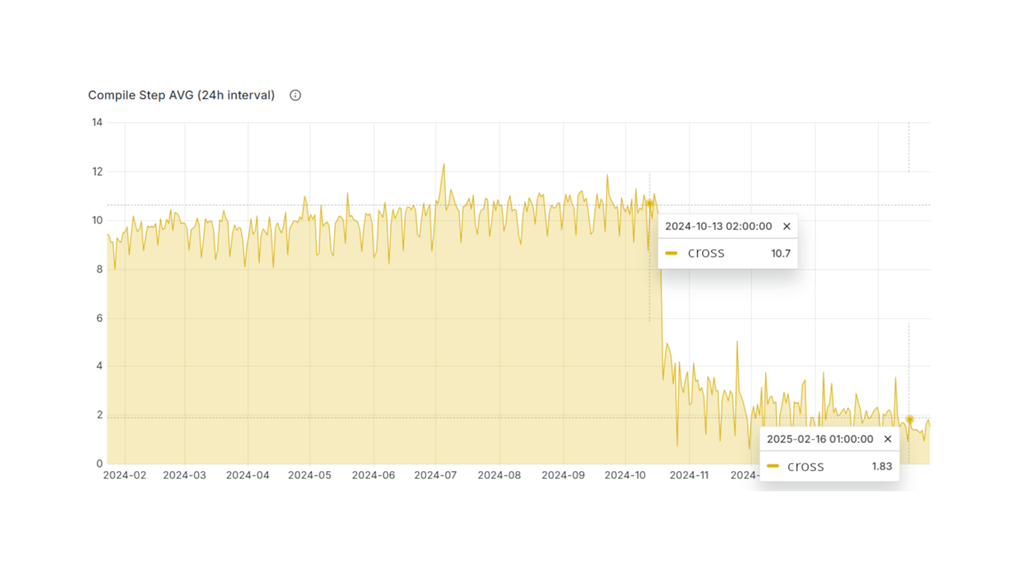

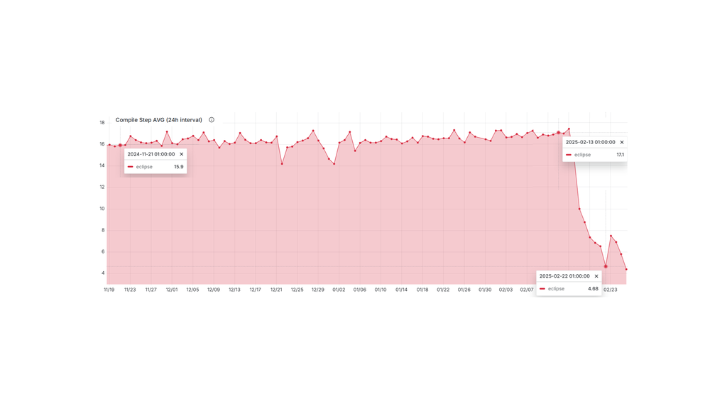

## Case Study: Obstacles

- The existing (test-)infrastructure assumes a polluted working copy (in-source build as opposed to out-of-source).
- Age of the project.
- Lost repository history (migration from ClearCase to Git).
- Poorly written commit messages.
- Developers have historically considered the build systems a black box.
- Developers were used to a “focused build” - a build that did not update dependencies.
- A management that is focussed on “customer value” and puts no emphasize at all on developer productivity.
- (Almost) No prior knowledge in Bazel.

## Migration: Don’t do it if any of the following is true:

- You cannot praise your management like these guys do.
  - [BazelCon 2019 Day 1: Building Self Driving Cars with Bazel](https://www.youtube.com/watch?v=RPhvb4VoXKY)
  - [Building Self Driving Cars with Bazel - Part 2: Scaling](https://www.youtube.com/watch?v=StZQCOs-lnw)
- Your feature-developing software engineers have historically been treating the build system as a black box.
  - Ask yourself: Is my average coworker a software craftsman with a carefully curated toolbox?
- You cannot assemble a platform team of highly-skilled (and highly-driven!) engineers.

## The Bazel Ecosystem

- [Bazel](https://bazel.build/)
- buildifier – formatter
- buildozer – build file transformations
- [Gazelle](https://github.com/bazel-contrib/bazel-gazelle) – a build file generator
- [BCR](https://registry.bazel.build/) – the Bazel Central Registry
  - Rules (extensions) for Bazel
  - third-party dependencies such as SQLite, Boost, Abseil, Catch2, Googletest, …
- [Remote Cache](https://github.com/buchgr/bazel-remote)
- [Remote Execution Services](https://bazel.build/community/remote-execution-services)
- [YouTube: bazelcon](https://www.youtube.com/results?search_query=bazelcon)

```
                                         It's about time for a demo
```

## Bazel: Removed from the Portage Tree

[output not shown]

- https://gitweb.gentoo.org/repo/gentoo.git/commit/profiles/package.mask?id=8968f9287c683d0fc9d46b87e4ac624c7c7b066e
- https://bugs.debian.org/cgi-bin/bugreport.cgi?bug=979699
- https://salsa.debian.org/bazel-team/meta
- https://archlinux.org/packages/extra/x86_64/bazel/
- https://bugzilla.redhat.com/show_bug.cgi?id=2238191

## Conclusion

- `clean` is an anti-pattern
- build files become increasingly abstract; there are at least two ways to deal with this
  - crank up the verbosity of the build system
  - understand the less powerful solutions first, then go on to the next
- `make`, `cmake`, `meson` and the likes are sufficient when massive scale is not (yet) a requirement
  - … because if used as intended, they provide the same *functional* guarantees that Bazel provides
- use Bazel when the former perform poorly on large projects
  - … and `ccache` is not sufficient, either
- that being said, the features provided by Bazel are a welcome addition
  - visibility at the build system level
  - introspection into the build system using queries
  - derivatives of the build with Aspects

```
                                         Thank you for your attention.

                                                   Questions?
```

## Nerd Slide

… because I can’t focus when watching a talk not knowing how the sausage was made.

```
                                |-- NeoVim with nvim-kickstart.lua (slightly modified)

                                |   `-- colorscheme is cyberdream-light (selected for high contrast)

                                |-- fzf

                            /-- zsh

                        /-- tmux

                    /-- foot terminal emulator

                        `-- font is FiraCode

                    |-- swayimg image viewer

                    |-- custom `status_command` using epoll, inotify and timerfd and a few lines of C++

                /-- sway window manager

            /-- Exherbo

        /-- Linux 6.15.4
```